# Bay Wheels Jun - Jul 2020

## Introduction

This project will explore the data for Bay Wheels(Ford GoBike). The goal is to gain insights over this public bicycle sharing in the San Francisco Bay Area, California.

Bay Wheels is a regional public bicycle sharing system in the San Francisco Bay Area, California operated by Motivate in a partnership with the Metropolitan Transportation Commission and the Bay Area Air Quality Management District. Bay Wheels is the first regional and large-scale bicycle sharing system deployed in California and on the West Coast of the United States. It was established as Bay Area Bike Share in August 2013. As of January 2018, the Bay Wheels system had over 2,600 bicycles in 262 stations across San Francisco, East Bay and San Jose. On June 28, 2017, the system officially re-launched as Ford GoBike in a partnership with Ford Motor Company. After Motivate's acquisition by Lyft, the system was subsequently renamed to Bay Wheels in June 2019. The system is expected to expand to 7,000 bicycles around 540 stations in San Francisco, Oakland, Berkeley, Emeryville, and San Jose.

Source: Wikipedia (https://en.wikipedia.org/wiki/Bay_Wheels)

- Preliminary Wrangling
- Data Cleaning
- Univariate Exploration
- Bivariate Exploration
- Multivariate Exploration

## Preliminary Wrangling

```python
# import all packages and set plots to be embedded inline
import numpy as np
import pandas as pd
import matplotlib.pyplot as plt
import seaborn as sns

%matplotlib inline
```

```python
trip_data = pd.read_csv('/Users/macbook/Documents/udacity/findings/202006-baywheels-tripdata.csv')
```

```python
trip_data.shape
```

```
(158168, 13)
```

```python
trip_data.info()
```

```
<class 'pandas.core.frame.DataFrame'>
RangeIndex: 158168 entries, 0 to 158167
Data columns (total 13 columns):
ride_id               158168 non-null object
rideable_type         158168 non-null object
started_at            158168 non-null object
ended_at              158168 non-null object
start_station_name    99220 non-null object
start_station_id      99220 non-null float64
end_station_name      97151 non-null object
end_station_id        97151 non-null float64
start_lat             158168 non-null float64
start_lng             158168 non-null float64
end_lat               157892 non-null float64
end_lng               157892 non-null float64
member_casual         158168 non-null object
dtypes: float64(6), object(7)
memory usage: 15.7+ MB
```

```python
trip_data.sample(5)
```

|  | ride_id | rideable_type | started_at | ended_at | start_station_name | start_station_id | end_station_name | end_station_id | start_lat | start_lng | end_lat | end_lng | member_casual |
| --- | --- | --- | --- | --- | --- | --- | --- | --- | --- | --- | --- | --- | --- |
| 106271 | 3B9D9DD3A080D521 | docked_bike | 2020-06-03 16:56:04 | 2020-06-03 17:08:59 | Berry St at King St | 91.0 | Pier 1/2 at The Embarcadero | 12.0 | 37.771762 | -122.398437 | 37.796389 | -122.394586 | member |
| 122571 | E3977B456EBECE7E | electric_bike | 2020-06-08 06:51:57 | 2020-06-08 07:03:18 | Page St at Scott St | 72.0 | 22nd St at Potrero Ave | 518.0 | 37.772390 | -122.435840 | 37.756876 | -122.406038 | member |
| 38745 | DA83AFD4F07445BA | electric_bike | 2020-06-02 17:23:41 | 2020-06-02 17:41:18 | NaN | NaN | NaN | NaN | 37.790000 | -122.400000 | 37.770000 | -122.430000 | casual |
| 41391 | 356F76E432208DE6 | electric_bike | 2020-06-15 16:38:25 | 2020-06-15 16:49:08 | NaN | NaN | Valencia St at 21st St | 127.0 | 37.770000 | -122.440000 | 37.756901 | -122.421092 | casual |
| 156063 | D6D04E3BC74625B8 | docked_bike | 2020-06-17 16:34:41 | 2020-06-17 16:41:58 | Post St at Kearny St | 19.0 | Market St at Steuart St | 16.0 | 37.788975 | -122.403452 | 37.794497 | -122.394838 | casual |

## Data Cleaning

I will better prepare the in order to be able to answer the posed questions.

- I will handle the cleaning missing values by removing or imputing them
- Drop unnecessary columns and rows
- Change data types to better support the analysis
- Replace unwanted characters
- Create and encode columns

```python
trip_data_clean = trip_data.copy()
```

```python
#check null values in each data set
```

```python
trip_data_clean.isnull().sum()
```

```
ride_id                   0
rideable_type             0
started_at                0
ended_at                  0
start_station_name    58948
start_station_id      58948
end_station_name      61017
end_station_id        61017
start_lat                 0
start_lng                 0
end_lat                 276
end_lng                 276
member_casual             0
dtype: int64
```

```python
#drop rows with missing values
```

```python
trip_data_clean = trip_data_clean.dropna()
trip_data_clean = trip_data_clean.reset_index(drop=True)
```

```python
trip_data_clean.isnull().sum()
```

```
ride_id               0
rideable_type         0
started_at            0
ended_at              0
start_station_name    0
start_station_id      0
end_station_name      0
end_station_id        0
start_lat             0
start_lng             0
end_lat               0
end_lng               0
member_casual         0
dtype: int64
```

```python
#check for duplicate entries
```

```python
sum(trip_data_clean.duplicated())
```

```
0
```

```python
#fix data types
```

```python
trip_data_clean.dtypes
```

```
ride_id                object
rideable_type          object
started_at             object
ended_at               object
start_station_name     object
start_station_id      float64
end_station_name       object
end_station_id        float64
start_lat             float64
start_lng             float64
end_lat               float64
end_lng               float64
member_casual          object
dtype: object
```

```python
trip_data_clean['rideable_type'] = trip_data_clean['rideable_type'].astype('category')
trip_data_clean['member_casual'] = trip_data_clean['member_casual'].astype('category')
```

```python
trip_data_clean['start_station_id'] = trip_data_clean['start_station_id'].astype('str')
trip_data_clean['end_station_id'] = trip_data_clean['end_station_id'].astype('str')
trip_data_clean['ride_id'] = trip_data_clean['ride_id'].astype('str')
```

```python
trip_data_clean.info()
```

```
<class 'pandas.core.frame.DataFrame'>
RangeIndex: 79900 entries, 0 to 79899
Data columns (total 13 columns):
ride_id               79900 non-null object
rideable_type         79900 non-null category
started_at            79900 non-null object
ended_at              79900 non-null object
start_station_name    79900 non-null object
start_station_id      79900 non-null object
end_station_name      79900 non-null object
end_station_id        79900 non-null object
start_lat             79900 non-null float64
start_lng             79900 non-null float64
end_lat               79900 non-null float64
end_lng               79900 non-null float64
member_casual         79900 non-null category
dtypes: category(2), float64(4), object(7)
memory usage: 6.9+ MB
```

```python
#Change started_at and ended_at to datetime format
```

```python
from datetime import datetime
import calendar
import time
```

```python
trip_data_clean['started_at'] = pd.to_datetime(trip_data_clean['started_at'])
trip_data_clean['ended_at'] = pd.to_datetime(trip_data_clean['ended_at'])
```

```python
# Extract date, hour, day of week, and month information from the started_at
```

```python
trip_data_clean['month'] = trip_data_clean['started_at'].dt.month
trip_data_clean['day_of_week'] = trip_data_clean['started_at'].dt.weekday_name
```

```python
trip_data_clean['start_at_month'] = trip_data_clean['started_at'].dt.strftime('%B')
```

```python
trip_data_clean['start_hour'] = trip_data_clean['started_at'].dt.hour
trip_data_clean['end_hour'] = trip_data_clean['ended_at'].dt.hour
```

```python
trip_data_clean.sample(5)
```

|  | ride_id | rideable_type | started_at | ended_at | start_station_name | start_station_id | end_station_name | end_station_id | start_lat | start_lng | end_lat | end_lng | member_casual | month | day_of_week | start_at_month | start_hour | end_hour |
| --- | --- | --- | --- | --- | --- | --- | --- | --- | --- | --- | --- | --- | --- | --- | --- | --- | --- | --- |
| 75792 | F85A1A3F7D72CEE9 | docked_bike | 2020-06-29 08:53:53 | 2020-06-29 09:00:15 | 22nd St at Dolores St | 131.0 | 17th & Folsom Street Park (17th St at Folsom St) | 110.0 | 37.755000 | -122.425727 | 37.763708 | -122.415204 | casual | 6 | Monday | June | 8 | 9 |
| 25181 | 2FE8B8C9200E3B98 | docked_bike | 2020-06-17 20:08:03 | 2020-06-17 20:26:40 | Telegraph Ave at 23rd St | 180.0 | El Embarcadero at Grand Ave | 197.0 | 37.812678 | -122.268772 | 37.808848 | -122.249680 | casual | 6 | Wednesday | June | 20 | 20 |
| 54572 | 2E416EA08D8B60FB | electric_bike | 2020-06-26 17:15:27 | 2020-06-26 17:47:33 | Clement St at 32nd Ave | 516.0 | 20th St at Dolores St | 381.0 | 37.781665 | -122.492839 | 37.758271 | -122.426095 | member | 6 | Friday | June | 17 | 17 |
| 44191 | 7B63D4D216BB752E | docked_bike | 2020-06-19 13:15:11 | 2020-06-19 13:35:43 | Frank H Ogawa Plaza | 7.0 | Grand Ave at Santa Clara Ave | 193.0 | 37.804562 | -122.271738 | 37.812744 | -122.247215 | member | 6 | Friday | June | 13 | 13 |
| 32410 | B317DBDFA7E606EF | docked_bike | 2020-06-19 10:48:04 | 2020-06-19 11:00:32 | Arguello Blvd at Edward St | 486.0 | 23rd Ave at Clement St | 520.0 | 37.778486 | -122.458645 | 37.781990 | -122.482807 | member | 6 | Friday | June | 10 | 11 |

```python
trip_data_clean['duration'] = trip_data_clean['ended_at'] - trip_data_clean['started_at']
```

```python
trip_data_clean['duration_sec'] = trip_data_clean['duration'].dt.seconds
```

```python
trip_data_clean['duration_minutes'] = trip_data_clean['duration_sec']/60
```

```python
trip_data_clean.sample(5)
```

|  | ride_id | rideable_type | started_at | ended_at | start_station_name | start_station_id | end_station_name | end_station_id | start_lat | start_lng | ... | end_lng | member_casual | month | day_of_week | start_at_month | start_hour | end_hour | duration | duration_sec | duration_minutes |
| --- | --- | --- | --- | --- | --- | --- | --- | --- | --- | --- | --- | --- | --- | --- | --- | --- | --- | --- | --- | --- | --- |
| 19790 | 142EB58E8BD1C320 | docked_bike | 2020-06-03 21:11:17 | 2020-06-03 21:28:49 | S Van Ness Ave at Market St | 59.0 | Utah St at 24th St | 459.0 | 37.774814 | -122.418954 | ... | -122.405393 | casual | 6 | Wednesday | June | 21 | 21 | 00:17:32 | 1052 | 17.533333 |
| 417 | 94C85EE650C4EB24 | electric_bike | 2020-06-25 08:03:02 | 2020-06-25 08:18:49 | The Embarcadero at Sansome St | 6.0 | 4th St at 16th St | 104.0 | 37.804814 | -122.403325 | ... | -122.390507 | casual | 6 | Thursday | June | 8 | 8 | 00:15:47 | 947 | 15.783333 |
| 67327 | 3BD34081E5463DF4 | electric_bike | 2020-06-10 14:06:13 | 2020-06-10 14:11:47 | 11th St at Natoma St | 77.0 | Valencia St at 16th St | 98.0 | 37.773468 | -122.415995 | ... | -122.421819 | member | 6 | Wednesday | June | 14 | 14 | 00:05:34 | 334 | 5.566667 |
| 3355 | 94074EB5EFC58646 | electric_bike | 2020-06-29 06:42:16 | 2020-06-29 06:47:53 | McAllister St at Arguello Blvd | 455.0 | Frederick St at Arguello Blvd | 458.0 | 37.775313 | -122.458082 | ... | -122.457601 | casual | 6 | Monday | June | 6 | 6 | 00:05:37 | 337 | 5.616667 |
| 78093 | 5EF1B718F91235D1 | electric_bike | 2020-06-13 12:26:28 | 2020-06-13 12:33:09 | 17th St at Valencia St | 109.0 | 11th St at Bryant St | 88.0 | 37.763278 | -122.422165 | ... | -122.411913 | member | 6 | Saturday | June | 12 | 12 | 00:06:41 | 401 | 6.683333 |

5 rows × 21 columns

```python
trip_data_clean.info()
```

```
<class 'pandas.core.frame.DataFrame'>
RangeIndex: 79900 entries, 0 to 79899
Data columns (total 21 columns):
ride_id               79900 non-null object
rideable_type         79900 non-null category
started_at            79900 non-null datetime64[ns]
ended_at              79900 non-null datetime64[ns]
start_station_name    79900 non-null object
start_station_id      79900 non-null object
end_station_name      79900 non-null object
end_station_id        79900 non-null object
start_lat             79900 non-null float64
start_lng             79900 non-null float64
end_lat               79900 non-null float64
end_lng               79900 non-null float64
member_casual         79900 non-null category
month                 79900 non-null int64
day_of_week           79900 non-null object
start_at_month        79900 non-null object
start_hour            79900 non-null int64
end_hour              79900 non-null int64
duration              79900 non-null timedelta64[ns]
duration_sec          79900 non-null int64
duration_minutes      79900 non-null float64
dtypes: category(2), datetime64[ns](2), float64(5), int64(4), object(7), timedelta64[ns](1)
memory usage: 11.7+ MB
```

```python
#create 'ride_distance' column from latitude and longitude
```

```python
# source of the code: Stackoverflow
#(https://stackoverflow.com/questions/19412462/getting-distance-between-two-points-based-on-latitude-longitude)
from math import sin, cos, sqrt, atan2, radians

def distance (lat1,lon1,lat2,lon2):
    R = 6373.0

    lat1 = radians(lat1)
    lon1 = radians(lon1)
    lat2 = radians(lat2)
    lon2 = radians(lon2)

    dlon = lon2 - lon1
    dlat = lat2 - lat1

    a = sin(dlat / 2)**2 + cos(lat1) * cos(lat2) * sin(dlon / 2)**2
    c = 2 * atan2(sqrt(a), sqrt(1 - a))

    distance = R * c
    return np.float64(round(1000*distance))
```

```python
trip_data_clean['ride_distance'] = trip_data_clean.apply(lambda row: distance(row['start_lat'],row['start_lng'],row['end_lat'],row['end_lng']),axis=1)
```

```python
#convert distance from meters to kilometers
```

```python
trip_data_clean['ride_distance_km'] = trip_data_clean['ride_distance']/1000
```

```python
trip_data_clean.info()
```

```
<class 'pandas.core.frame.DataFrame'>
RangeIndex: 79900 entries, 0 to 79899
Data columns (total 23 columns):
ride_id               79900 non-null object
rideable_type         79900 non-null category
started_at            79900 non-null datetime64[ns]
ended_at              79900 non-null datetime64[ns]
start_station_name    79900 non-null object
start_station_id      79900 non-null object
end_station_name      79900 non-null object
end_station_id        79900 non-null object
start_lat             79900 non-null float64
start_lng             79900 non-null float64
end_lat               79900 non-null float64
end_lng               79900 non-null float64
member_casual         79900 non-null category
month                 79900 non-null int64
day_of_week           79900 non-null object
start_at_month        79900 non-null object
start_hour            79900 non-null int64
end_hour              79900 non-null int64
duration              79900 non-null timedelta64[ns]
duration_sec          79900 non-null int64
duration_minutes      79900 non-null float64
ride_distance         79900 non-null float64
ride_distance_km      79900 non-null float64
dtypes: category(2), datetime64[ns](2), float64(7), int64(4), object(7), timedelta64[ns](1)
memory usage: 13.0+ MB
```

```python
trip_data_clean.sample(5)
```

|  | ride_id | rideable_type | started_at | ended_at | start_station_name | start_station_id | end_station_name | end_station_id | start_lat | start_lng | ... | month | day_of_week | start_at_month | start_hour | end_hour | duration | duration_sec | duration_minutes | ride_distance | ride_distance_km |
| --- | --- | --- | --- | --- | --- | --- | --- | --- | --- | --- | --- | --- | --- | --- | --- | --- | --- | --- | --- | --- | --- |
| 8964 | 7B8D91CD0BAD2D36 | electric_bike | 2020-06-06 23:54:00 | 2020-06-07 00:03:40 | Bay St at Fillmore St | 399.0 | Scott St at Golden Gate Ave | 39.0 | 37.802619 | -122.435980 | ... | 6 | Saturday | June | 23 | 0 | 00:09:40 | 580 | 9.666667 | 2598.0 | 2.598 |
| 24389 | C91CF4F4F8186498 | electric_bike | 2020-06-13 13:19:29 | 2020-06-13 14:05:17 | Embarcadero BART Station (Beale St at Market St) | 17.0 | Hyde St at Post St | 369.0 | 37.791601 | -122.397301 | ... | 6 | Saturday | June | 13 | 14 | 00:45:48 | 2748 | 45.800000 | 1781.0 | 1.781 |
| 62522 | 3E7E430497644D77 | docked_bike | 2020-06-11 15:30:24 | 2020-06-11 16:44:24 | Grove St at Gough St | 468.0 | Grove St at Gough St | 468.0 | 37.777870 | -122.422952 | ... | 6 | Thursday | June | 15 | 16 | 01:14:00 | 4440 | 74.000000 | 0.0 | 0.000 |
| 61325 | 35184EE0B0305B69 | electric_bike | 2020-06-17 10:00:28 | 2020-06-17 10:20:58 | Randall St at Chenery St | 387.0 | Howard St at 8th St | 61.0 | 37.739844 | -122.425358 | ... | 6 | Wednesday | June | 10 | 10 | 00:20:30 | 1230 | 20.500000 | 4287.0 | 4.287 |
| 3696 | AB25995B80DCCA9A | electric_bike | 2020-06-02 07:37:50 | 2020-06-02 07:53:53 | Eureka Valley Recreation Center | 118.0 | Grove St at Gough St | 468.0 | 37.759219 | -122.436775 | ... | 6 | Tuesday | June | 7 | 7 | 00:16:03 | 963 | 16.050000 | 2399.0 | 2.399 |

5 rows × 23 columns

```python
trip_data_clean.shape
```

```
(79900, 23)
```

### What is the structure of your dataset?

This dataset contains information from the start of the month of June to the start of the month of July 2020.

The columns include information regarding the bikes rented such as when and where the rental started and ended, how long the ride was and some information about the costumer.

### What is/are the main feature(s) of interest in your dataset?

My interest is in exploring the bike trips patterns, such as where is the most commom begining and end station, what is the average duration of rides , at what time of the day more bikes are rented, what day of the week receives more rentals, what is the prefered type of ride, and who uses more this service subscribers or casual customers.

### What features in the dataset do you think will help support your investigation into your feature(s) of interest?

duration, start and end station, start_day, start_hour, member_casual, rideable_type, ride_distance_km

## Univariate Exploration

**Let's start exploring the categorical variables**

```python
color_base = sns.color_palette()[0]
```

```python
#types of rides count
```

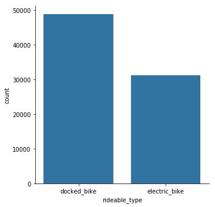

```python
sns.catplot(data=trip_data_clean, x='rideable_type', kind = 'count', color = color_base);
```

```python
#type of user count
```

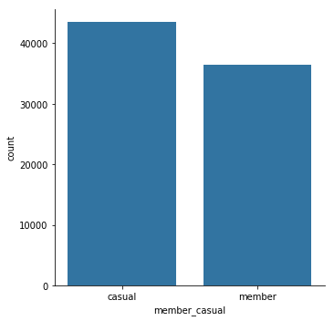

```python
sns.catplot(data=trip_data_clean, x='member_casual', kind = 'count', color = color_base);
```

```python
#Number of rides per day of the week
```

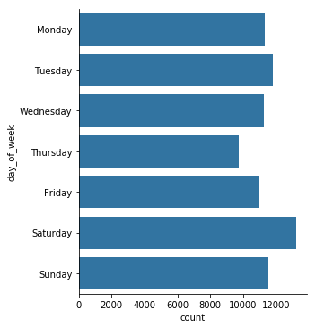

```python
weekday = ['Monday', 'Tuesday', 'Wednesday', 'Thursday', 'Friday', 'Saturday', 'Sunday']

sns.catplot(data=trip_data_clean, y='day_of_week', kind = 'count', color = color_base, order = weekday);
```

```python
#start hour
```

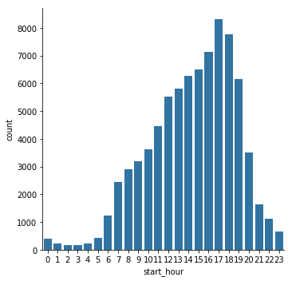

```python
sns.catplot(data=trip_data_clean, x='start_hour', kind = 'count', color = color_base);
```

**Let's look at some statistics for our categorical variables**

```python
trip_data_clean.describe(exclude=[np.number])
```

|  | ride_id | rideable_type | started_at | ended_at | start_station_name | start_station_id | end_station_name | end_station_id | member_casual | day_of_week | start_at_month |
| --- | --- | --- | --- | --- | --- | --- | --- | --- | --- | --- | --- |
| count | 79900 | 79900 | 79900 | 79900 | 79900 | 79900 | 79900 | 79900 | 79900 | 79900 | 79900 |
| unique | 79900 | 2 | 77524 | 77443 | 426 | 426 | 431 | 431 | 2 | 7 | 1 |
| top | 7A034F38BA46FF64 | docked_bike | 2020-06-18 18:39:10 | 2020-06-26 19:59:16 | Market St at 10th St | 58.0 | Market St at 10th St | 58.0 | casual | Saturday | June |
| freq | 1 | 48716 | 4 | 3 | 1209 | 1209 | 1168 | 1168 | 43470 | 13230 | 79900 |
| first | NaN | NaN | 2020-06-01 00:02:16 | 2020-06-01 00:18:14 | NaN | NaN | NaN | NaN | NaN | NaN | NaN |
| last | NaN | NaN | 2020-06-30 23:58:39 | 2020-07-04 20:18:03 | NaN | NaN | NaN | NaN | NaN | NaN | NaN |

```python
user_types_proportion =trip_data_clean['member_casual'].value_counts(normalize=True)*100

print(user_types_proportion)
```

```
casual    54.405507
member    45.594493
Name: member_casual, dtype: float64
```

```python
popular_ride = trip_data_clean['rideable_type'].mode()[0]

print('Most Popular Ride:', popular_ride)
```

```
Most Popular Ride: docked_bike
```

```python
popular_day = trip_data_clean['day_of_week'].mode()[0]

print('Most Popular Start Day:', popular_day)
```

```
Most Popular Start Day: Saturday
```

```python
popular_hour = trip_data_clean['start_hour'].mode()[0]

print('Most Popular Start Hour:', popular_hour)
```

```
Most Popular Start Hour: 17
```

```python
popular_start_station = trip_data_clean['start_station_name'].mode()[0]

print('Most Popular Start Station:', popular_start_station)
```

```
Most Popular Start Station: Market St at 10th St
```

```python
popular_start_station = trip_data_clean['end_station_name'].mode()[0]

print('Most Popular End Station:', popular_start_station)
```

```
Most Popular End Station: Market St at 10th St
```

```python
#most frequent combination of start station and end station trip

trip_data_clean['Start and End Sations'] = trip_data_clean['start_station_name'] + ' ' + 'to' + ' ' + trip_data_clean['end_station_name']
popular_route = trip_data_clean ['Start and End Sations'].mode()[0]

print('The most popular route station is:', popular_route)
```

```
The most popular route station is: El Embarcadero at Grand Ave to El Embarcadero at Grand Ave
```

## FINDINGS

**rideable_type**

There are 2 unique rideable types. The most commom is the docked bike.

**start_station_name**

There are 426 start stations, which makes it very difficult to plot. The most frequently used start station is Market St at 10th St.

**end_station_name**

There are 431 end stations, which also makes it very difficult to plot. The most frequently used end station is also Market St at 10th St.

However, the most popular route station is from El Embarcadero at Grand Ave to El Embarcadero at Grand Ave.

**member_casual**

Most customers are casual, they use the service as needed withou subscribing to a membership. There are 43470 casual customers. They represent almost 55% of users.

**start_hour**

The peak hours for the service are between 17:00 and 18:00. The most commom start hour is 17:00.

**day_of_week**

The most popular day for renting a bike is Saturday.

**Now let's explore our numeric variables**

```python
trip_data_clean[['duration_minutes', 'ride_distance_km']].describe()
```

|  | duration_minutes | ride_distance_km |
| --- | --- | --- |
| count | 79900.000000 | 79900.000000 |
| mean | 22.745545 | 1.868413 |
| std | 53.782437 | 1.503945 |
| min | 0.000000 | 0.000000 |
| 25% | 7.766667 | 0.740000 |
| 50% | 13.775000 | 1.593000 |
| 75% | 24.333333 | 2.748000 |
| max | 1439.983333 | 16.896000 |

```python
average_distance = trip_data_clean['ride_distance_km'].mean()

print('The average distance (km) of a bike ride is:', average_distance)
```

```
The average distance (km) of a bike ride is: 1.8684132540675822
```

```python
mean_travel_time = trip_data_clean['duration_minutes'].mean()
print('The mean travel time in minutes was:', round(mean_travel_time))
```

```
The mean travel time in minutes was: 23
```

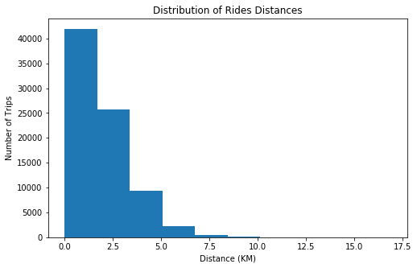

```python
plt.figure(figsize=[8, 5])
plt.hist(data = trip_data_clean, x = 'ride_distance_km')
plt.title('Distribution of Rides Distances')
plt.xlabel('Distance (KM)')
plt.ylabel('Number of Trips')
plt.show()
```

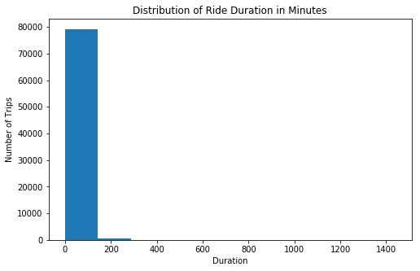

```python
plt.figure(figsize=[8, 5])
plt.hist(data = trip_data_clean, x = 'duration_minutes')
plt.title('Distribution of Ride Duration in Minutes')
plt.xlabel('Duration')
plt.ylabel('Number of Trips')
plt.show()
```

Let's check the top precentile.

```python
trip_data_clean['duration_minutes'].describe(percentiles=[.95])
```

```
count    79900.000000
mean        22.745545
std         53.782437
min          0.000000
50%         13.775000
95%         61.900000
max       1439.983333
Name: duration_minutes, dtype: float64
```

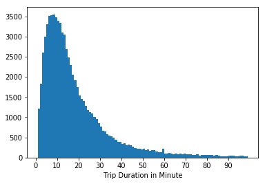

```python
bins = np.arange(1, 100, 1)
ticks = np.arange(0, 100, 10)
plt.hist(data=trip_data_clean, x='duration_minutes', bins=bins);
plt.xticks(ticks, ticks);
plt.xlabel('Trip Duration in Minute');
```

From the graph it seems that most rides are short.

```python
#keep this data for further analysis
```

```python
trip_data_clean = trip_data_clean.query('duration_minutes <= 100')
trip_data_clean.info(null_counts=True)
```

```
<class 'pandas.core.frame.DataFrame'>
Int64Index: 78236 entries, 0 to 79899
Data columns (total 24 columns):
ride_id                  78236 non-null object
rideable_type            78236 non-null category
started_at               78236 non-null datetime64[ns]
ended_at                 78236 non-null datetime64[ns]
start_station_name       78236 non-null object
start_station_id         78236 non-null object
end_station_name         78236 non-null object
end_station_id           78236 non-null object
start_lat                78236 non-null float64
start_lng                78236 non-null float64
end_lat                  78236 non-null float64
end_lng                  78236 non-null float64
member_casual            78236 non-null category
month                    78236 non-null int64
day_of_week              78236 non-null object
start_at_month           78236 non-null object
start_hour               78236 non-null int64
end_hour                 78236 non-null int64
duration                 78236 non-null timedelta64[ns]
duration_sec             78236 non-null int64
duration_minutes         78236 non-null float64
ride_distance            78236 non-null float64
ride_distance_km         78236 non-null float64
Start and End Sations    78236 non-null object
dtypes: category(2), datetime64[ns](2), float64(7), int64(4), object(8), timedelta64[ns](1)
memory usage: 13.9+ MB
```

## FINDINGS

**ride_distance_km**

Most customers ride a short distance. The average ridings distance is nearly 2km.

**duration_minutes**

There are outliers in this set. An user apperently rode for an entire day (24 hours). But after removing this outlier it is possible to see that most rides are short in terms of time too.

### Of the features you investigated, were there any unusual distributions? Did you perform any operations on the data to tidy, adjust, or change the form of the data? If so, why did you do this?

> Most variables were within the expected distributions. The duration in minutes and even the distance had some outliers. The duration in minutes outlier was removed from our second plot so that we could see better the distribution of time per ride.

```python
# save the clean data to a .csv file
```

```python
trip_data_clean.to_csv('trip_data_clean.csv', index=False)
```

## Bivariate Exploration

**In this section I will explore the behaviour of user types and compare them across our other variables of interest.**

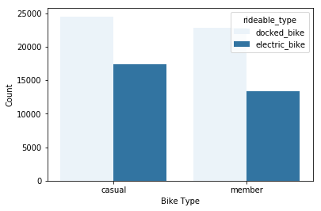

```python
sns.countplot(data=trip_data_clean, x='member_casual', hue='rideable_type', color=color_base);
plt.xlabel('Bike Type');
plt.ylabel('Count');
```

It seems that both casual and members have a preference for docked bike.

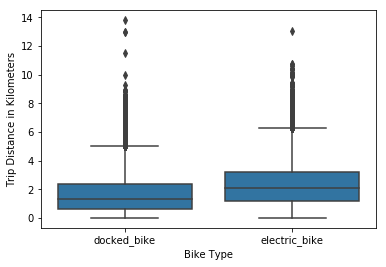

```python
sns.boxplot(data=trip_data_clean, x='rideable_type', y='ride_distance_km', color=color_base);
plt.xlabel('Bike Type');
plt.ylabel('Trip Distance in Kilometers');
```

It appears that the average distance for a ride on an eletric bike is longer than a docked bike.

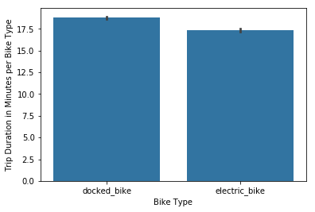

```python
sns.barplot(data=trip_data_clean, x='rideable_type', y='duration_minutes', color=color_base);
plt.xlabel('Bike Type');
plt.ylabel('Trip Duration in Minutes per Bike Type');
```

It seems that docked bikes trips runs a little longer than eletric bikes.

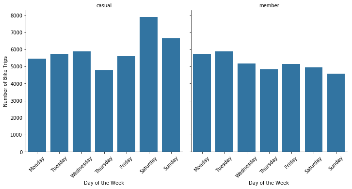

```python
weekday = ['Monday', 'Tuesday', 'Wednesday', 'Thursday', 'Friday', 'Saturday', 'Sunday']

graph = sns.catplot(data=trip_data_clean, x='day_of_week', col='member_casual', kind='count', sharey = True, color = color_base, order = weekday);

graph.set_axis_labels('Day of the Week', 'Number of Bike Trips');
graph.set_titles('{col_name}')
graph.set_xticklabels(rotation=45);
```

Casual and members seems to have a balanced usage of the system during the week days, while on weekends casual user seems to use the system more frequently.

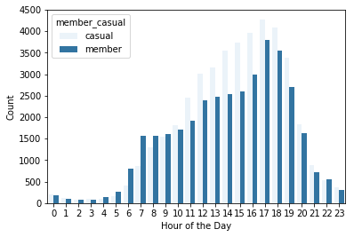

```python
sns.countplot(data=trip_data_clean, x='start_hour', hue='member_casual', color = color_base);
plt.xlabel('Hour of the Day');
plt.ylabel('Count');
```

It seems that in the most early hours of the day, members are most active, probably going to work or school. While after 10 o'clock it seems that casual users become more active.

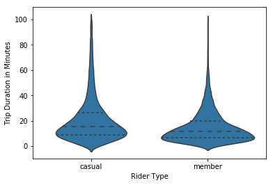

```python
sns.violinplot(data=trip_data_clean, x='member_casual', y='duration_minutes', color=color_base, inner='quartile');
plt.xlabel('Rider Type');
plt.ylabel('Trip Duration in Minutes');
```

Casual riders seem to rent the bikes for longer periods of time then members. While members has a shorter, narrower trip distribution than the others.

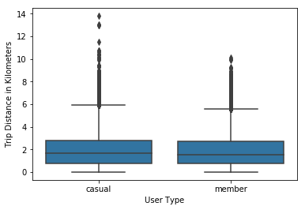

```python
sns.boxplot(data=trip_data_clean, x='member_casual', y='ride_distance_km', color=color_base);
plt.xlabel('User Type');
plt.ylabel('Trip Distance in Kilometers');
```

It seems that there is little difference between the average distance a casual user rides, compared to the distance ridden by a member.

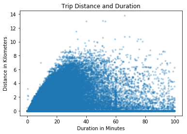

```python
plt.scatter(trip_data_clean['duration_minutes'], trip_data_clean['ride_distance_km'], alpha = 0.25, marker = '.' )
plt.title('Trip Distance and Duration')
plt.xlabel('Duration in Minutes')
plt.ylabel('Distance in Kilometers')
plt.show()
```

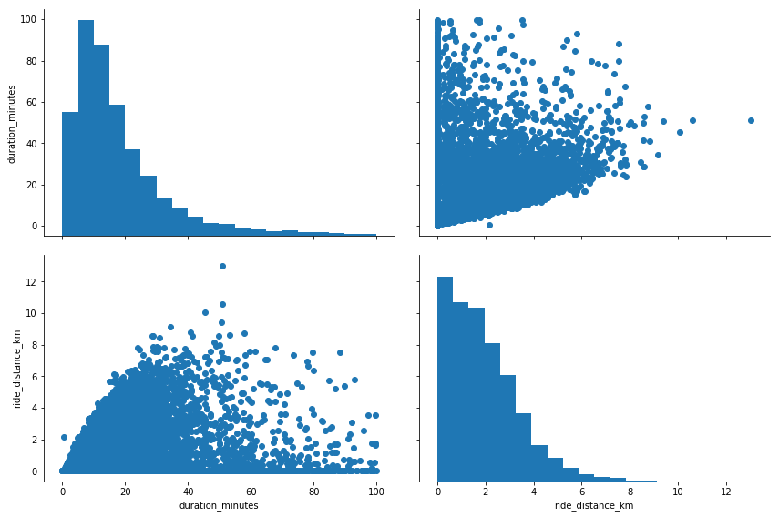

```python
samples = np.random.choice(trip_data_clean.shape[0], 10000, replace = False)
samp = trip_data_clean.loc[samples,:]

g = sns.PairGrid(data = samp, vars = trip_data_clean[['duration_minutes', 'ride_distance_km']], height = 4, aspect = 1.5)
g = g.map_diag(plt.hist, bins = 20);
g.map_offdiag(plt.scatter);
```

This does not look like a linear relationship. Distance does not go much further than 8 km while trip times continue to go on.

### Talk about some of the relationships you observed in this part of the investigation. How did the feature(s) of interest vary with other features in the dataset?

> The analysis of user behavior between casual and member users, revealed that casual riders are most likely tourists or just people on a day off, since this type o user usually takes longer trips in terms of minutes and of distance, also their peak usage is during the weekends. On the other hand member users seem to use the bike service to commute to work or school and their rides are mostly for shorter periods of time and distances. They rent the bikes mainly on week days at times that match those of start of school and work and the end of those activities.

> When it comes to bike types, it seems that both casual and members have a preference for docked bike. Also, eletric bikes go for longer distances, while docked bikes run for longer periods of time. This could be explained by the fact that eletric bikes may go faster, so the go farther in less time then the docked bikes.

### Did you observe any interesting relationships between the other features (not the main feature(s) of interest)?

> I would expect that the time of the ride and the distance has a more linear relationship. But it seems this is not the case here.

## Multivariate Exploration

> In this section I will continue to examine user type behaviour across other variables.

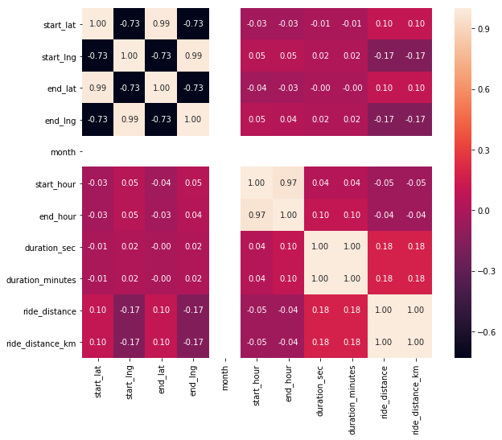

```python
f, ax = plt.subplots(figsize=(10, 8))
corr = trip_data_clean.corr()
sns.heatmap(corr, cbar = True, annot=True, square = True, fmt = '.2f', xticklabels=corr.columns.values, yticklabels=corr.columns.values);
```

The correlation map above does not indicate any interesting relationship between the numeric variables in our dataset.

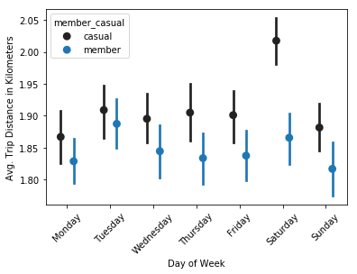

```python
weekday = ['Monday', 'Tuesday', 'Wednesday', 'Thursday', 'Friday', 'Saturday', 'Sunday']

sns.pointplot(data=trip_data_clean, x='day_of_week', y='ride_distance_km', hue='member_casual', dodge=0.3, linestyles='', color=color_base, order = weekday);
plt.xlabel('Day of Week');
plt.ylabel('Avg. Trip Distance in Kilometers');
plt.xticks(rotation=45);
```

Here we see again that casual users tend to ride for longer distances than subscribers. Saturday is the day in which longer distances are achieved.

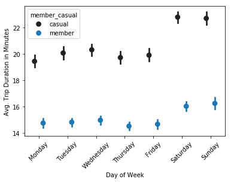

```python
weekday = ['Monday', 'Tuesday', 'Wednesday', 'Thursday', 'Friday', 'Saturday', 'Sunday']

sns.pointplot(data=trip_data_clean, x='day_of_week', y='duration_minutes', hue='member_casual', dodge=0.3, linestyles='', color=color_base, order = weekday);
plt.xlabel('Day of Week');
plt.ylabel('Avg. Trip Duration in Minutes')
plt.xticks(rotation=45);
```

This graph confirms that members usually ride for shorter periods of time and that on the Saturday the trip duration increases.

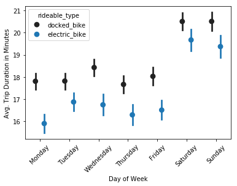

```python
weekday = ['Monday', 'Tuesday', 'Wednesday', 'Thursday', 'Friday', 'Saturday', 'Sunday']

sns.pointplot(data=trip_data_clean, x='day_of_week', y='duration_minutes', hue='rideable_type', dodge=0.3, linestyles='', color=color_base, order = weekday);
plt.xlabel('Day of Week');
plt.ylabel('Avg. Trip Duration in Minutes')
plt.xticks(rotation=45);
```

Docked bikes are ridden by longer periods of time every day of the week.

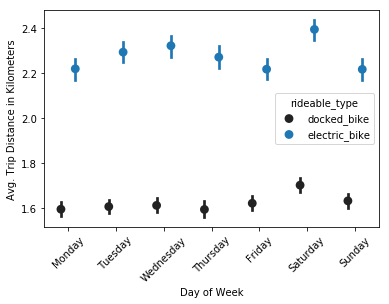

```python
weekday = ['Monday', 'Tuesday', 'Wednesday', 'Thursday', 'Friday', 'Saturday', 'Sunday']

sns.pointplot(data=trip_data_clean, x='day_of_week', y='ride_distance_km', hue='rideable_type', dodge=0.3, linestyles='', color=color_base, order = weekday);
plt.xlabel('Day of Week');
plt.ylabel('Avg. Trip Distance in Kilometers')
plt.xticks(rotation=45);
```

Eletric bikes are ridden by longer distances every day of the week.

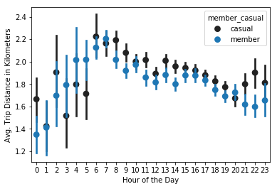

```python
sns.pointplot(data=trip_data_clean, x='start_hour', y='ride_distance_km', hue='member_casual', linestyles='', color=color_base);
plt.xlabel('Hour of the Day');
plt.ylabel('Avg. Trip Distance in Kilometers');
```

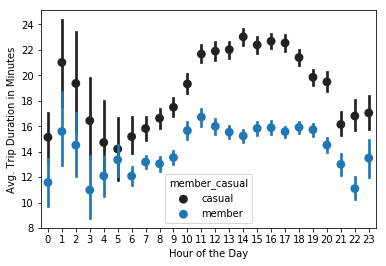

```python
sns.pointplot(data=trip_data_clean, x='start_hour', y='duration_minutes', hue='member_casual', linestyles='', color=color_base);
plt.xlabel('Hour of the Day');
plt.ylabel('Avg. Trip Duration in Minutes');
```

Members ride less minutes in all hours of the day.

### Talk about some of the relationships you observed in this part of the investigation. Were there features that strengthened each other in terms of looking at your feature(s) of interest?

> The multivariate exploration strengthened the behavior patterns uncovered in both univariate and bivariate exploration. Members tend to use more the service on week days and during rush hours. Their trips are likely to be commuting to work or school and are shorter in both time and distance. On the other hand, the casual user seems to use the bike more for leisure purposes. They start to ride more after 10 am and ride all day long ride for longer distances and for longer periods of time.

### Were there any interesting or surprising interactions between features?

> There was no big surprise in the data gathered. Perhaps an interesting fact is that casual and Member users seem to prefer non-electric bike. Although it is not clear from this data if this is a choice or if there are less electric bikes available for use. Even so, from this data it was possible to gather that electric bikes seem to be the bikes of choice for longer distances.